# Legacy (outdated) wrapper functions

For historic reasons, `ggrastr` used to be solely composed of the following functions:

- `geom_point_rast`: raster scatter plots
- `geom_jitter_rast`: raster jittered scatter plots
- `geom_boxplot_jitter`: boxplots that allows to jitter and rasterize outlier points
- `geom_tile_rast`: raster heatmap
- `geom_beeswarm_rast`: raster [bee swarm plots](https://github.com/eclarke/ggbeeswarm#geom_beeswarm)
- `geom_quasirandom_rast`: raster [quasirandom scatter plot](https://github.com/eclarke/ggbeeswarm#geom_quasirandom)

However, we strongly encourage users to use the `rasterise()` function instead. For posterity’s sake, we have only included the old vignettes here for the reference of users, along with the equivalent functions using `rasterise()`.

#### Points: Rasterize scatter plots with geom_point_rast()

Sometimes you need to publish a figure in a vector format:

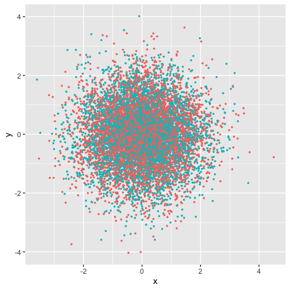

```r
library(ggplot2)
library(ggrastr)
points_num <- 10000
df <- data.frame(x=rnorm(points_num), y=rnorm(points_num), c=as.factor(1:points_num %% 2))
gg <- ggplot(df, aes(x=x, y=y, color=c)) + scale_color_discrete(guide="none")
gg_vec <- gg + geom_point(size=0.5)
print(gg_vec)
```

But in other cases, your figure contains thousands of points, e.g. try `points_num <- 500000` in the example above, and you will notice the performance issues—it takes significantly longer to render the plot.

In this case, a reasonable solution would be to rasterize the plot. But the problem is that all text becomes rasterized as well.

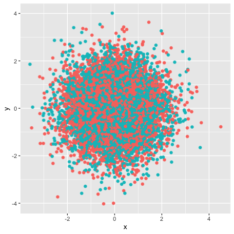

```r
gg_rasterized <- gg + rasterise(geom_point(), dpi = 300, scale = 1)
print(gg_rasterized)
```

The legacy function used in older versions of ggrastr was `geom_point_rast()`:

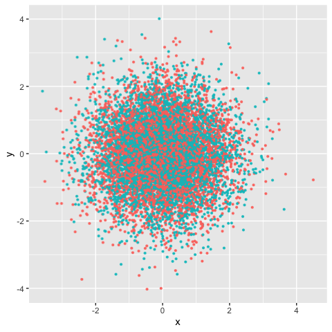

```r
gg_rast <- gg + geom_point_rast(size=0.5)
print(gg_rast)
```

The plots look the same, but the difference in size can be seen when they are exported to pdfs. Unfortunately, there is a longer rendering time to produce such plots:

```r
PrintFileSize <- function(gg, name) {
  invisible(ggsave('tmp.pdf', gg, width=4, height=4))
  cat(name, ': ', file.info('tmp.pdf')$size / 1024, ' Kb.\n', sep = '')
  unlink('tmp.pdf')
}
PrintFileSize(gg_rast, 'Raster')
```

```
#> Raster: 291.5576 Kb.
```

```r
PrintFileSize(gg_vec, 'Vector')
```

```
#> Vector: 556.1484 Kb.
```

As expected, the difference becomes larger with growth of number of points:

```r
points_num <- 1000000
df <- data.frame(x=rnorm(points_num), y=rnorm(points_num), c=as.factor(1:points_num %% 2))
gg <- ggplot(df, aes(x=x, y=y, color=c)) + scale_color_discrete(guide="none")
gg_vec <- gg + geom_point(size=0.5)
gg_rast <- gg + geom_point_rast(size=0.5)
PrintFileSize(gg_rast, 'Raster')
```

```
#> Raster: 358.6611 Kb.
```

```r
PrintFileSize(gg_vec, 'Vector')
```

```
#> Vector: 54786.11 Kb.
```

#### Jitter: Rasterize jittered scatter plots with geom_jitter_rast()

Users may also opt to create rasterized scatter plots with jitter:

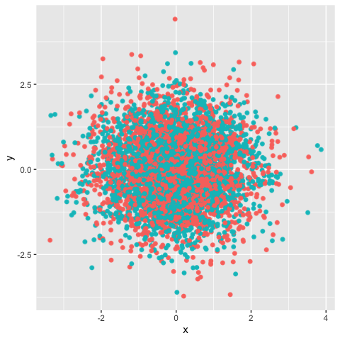

```r
library(ggplot2)
library(ggrastr)
points_num <- 5000
df <- data.frame(x=rnorm(points_num), y=rnorm(points_num), c=as.factor(1:points_num %% 2))
gg <- ggplot(df, aes(x=x, y=y, color=c)) + scale_color_discrete(guide="none")
gg_jitter_rast <- gg + rasterise(geom_jitter(), dpi = 300, scale = 1)
print(gg_jitter_rast)
```

The legacy wrapper `geom_jitter_rast()` used the following syntax:

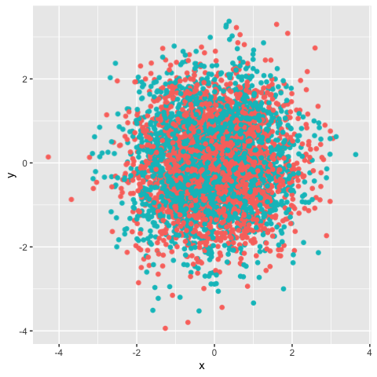

```r
library(ggplot2)
library(ggrastr)

points_num <- 5000
df <- data.frame(x=rnorm(points_num), y=rnorm(points_num), c=as.factor(1:points_num %% 2))
gg <- ggplot(df, aes(x=x, y=y, color=c)) + scale_color_discrete(guide=FALSE)

gg_jitter_rast <- gg + geom_jitter_rast(raster.dpi=600)
print(gg_jitter_rast)
```

#### Tiles: Rasterize heatmaps with geom_tile_rast()

Heatmaps also have similar issues with the default vectorized formats:

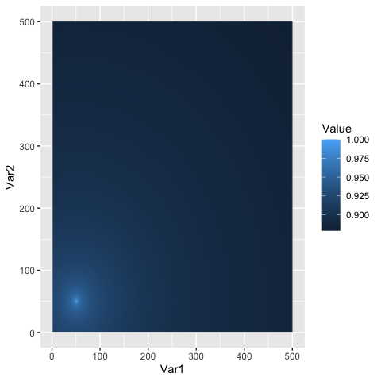

```r
library(ggplot2)
library(ggrastr)
coords <- expand.grid(1:500, 1:500)
coords$Value <- 1 / apply(as.matrix(coords), 1, function(x) sum((x - c(50, 50))^2)^0.01)
gg_tile_vec <- ggplot(coords) + geom_tile(aes(x=Var1, y=Var2, fill=Value))
gg_tile_rast <- ggplot(coords) + rasterise(geom_tile(aes(x=Var1, y=Var2, fill=Value)), dpi = 300, scale = 1)
print(gg_tile_rast)
```

The legacy function `geom_tile_rast()` used the following syntax:

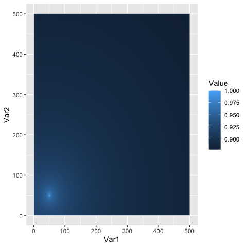

```r
gg_tile_rast <- ggplot(coords) + geom_tile_rast(aes(x=Var1, y=Var2, fill=Value))
print(gg_tile_rast)
```

Note that we can see that the rasterized plots using `ggrastr` are lighter in size when rendered to pdf:

```r
PrintFileSize(gg_tile_rast, 'Raster')
```

```
#> Raster: 46.77637 Kb.
```

```r
PrintFileSize(gg_tile_vec, 'Vector')
```

```
#> Vector: 817.8398 Kb.
```

#### Violin plots: Rasterize violin plots with geom_violin_rast()

One can see a similar effect with violin plots:

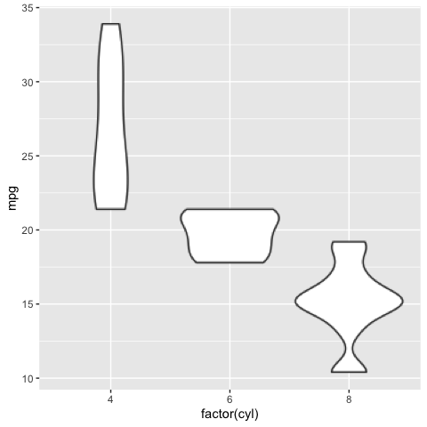

```r
library(ggplot2)
library(ggrastr)
gg_violin_vec <- ggplot(mtcars, aes(factor(cyl), mpg)) + geom_violin()
gg_violin_rast <- ggplot(mtcars) + rasterise(geom_violin(aes(factor(cyl), mpg)))
print(gg_violin_rast)
```

The legacy function `geom_violin_rast()` had the following syntax:

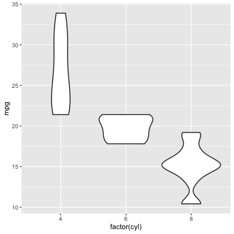

```r
gg_violin_rast <- ggplot(mtcars) + geom_violin_rast(aes(factor(cyl), mpg))
print(gg_violin_rast)
```

```r
## difference in size shown
PrintFileSize(gg_tile_rast, 'Raster')
```

```
#> Raster: 46.77637 Kb.
```

```r
PrintFileSize(gg_tile_vec, 'Vector')
```

```
#> Vector: 817.8398 Kb.
```

#### Box plots: Jitter outliers and rasterize box plots with geom_boxplot_jitter

Another type of plot with a potentially large number of small objects is geom_boxplot:

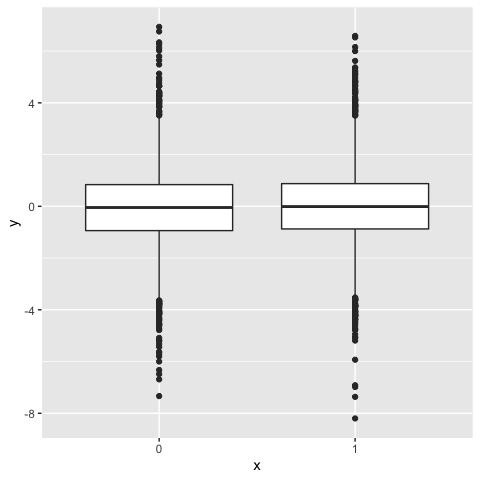

```r
library(ggplot2)
library(ggrastr)
points_num <- 5000
df <- data.frame(x=as.factor(1:points_num %% 2), y=log(abs(rcauchy(points_num))))
gg <- ggplot(df, aes(x=x, y=y)) + scale_color_discrete(guide="none")
boxplot <- gg + geom_boxplot()
print(boxplot)
```

For such a large number of points, it would be better to jitter them using `geom_boxplot_jitter()`:

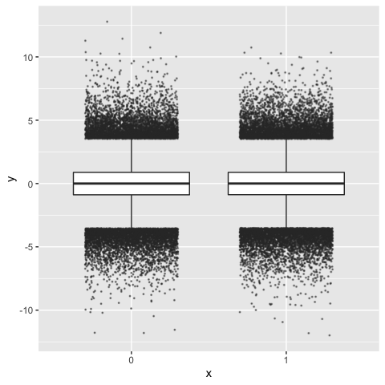

```r
library(ggplot2)
library(ggrastr)
points_num <- 500000
df <- data.frame(x=as.factor(1:points_num %% 2), y=log(abs(rcauchy(points_num))))
gg <- ggplot(df, aes(x=x, y=y)) + scale_color_discrete(guide="none")
gg_box_vec <- gg + geom_boxplot_jitter(outlier.size=0.1, outlier.jitter.width=0.3, outlier.alpha=0.5)
print(gg_box_vec)
```

And this geom can be rasterized as well:

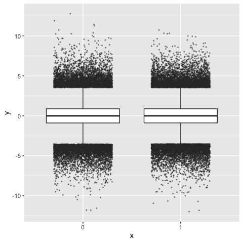

```r
gg_box_rast <- gg + geom_boxplot_jitter(outlier.size=0.1, outlier.jitter.width=0.3, outlier.alpha=0.5, raster.dpi=200)
print(gg_box_rast)
```

```r
PrintFileSize(gg_box_rast, 'Raster')
```

```
#> Raster: 122.5781 Kb.
```

```r
PrintFileSize(gg_box_vec, 'Vector')
```

```
#> Vector: 233.0508 Kb.
```

#### Beeswarm-style plots: geom_beeswarm_rast and geom_quasirandom

ggrastr also allows users to create rasterized beeswarm plots. As described in the README for ggbeeswarm,

> Beeswarm plots (aka column scatter plots or violin scatter plots) are a way of plotting points that would ordinarily overlap so that they fall next to each other instead. In addition to reducing overplotting, it helps visualize the density of the data at each point (similar to a violin plot), while still showing each data point individually. The ggrastr geom `geom_beeswarm_rast` is similar to `ggbeeswarm::geom_beeswarm()`, but it provides a rasterized layer:

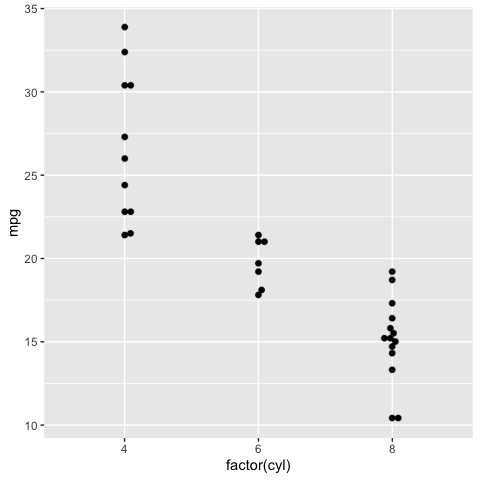

```r
library(ggplot2)
library(ggrastr)
ggplot(mtcars) + geom_beeswarm_rast(aes(x = factor(cyl), y=mpg), raster.dpi=600, cex=1.5)
```

Again, we strongly encourage users to simply use `rasterise()`:

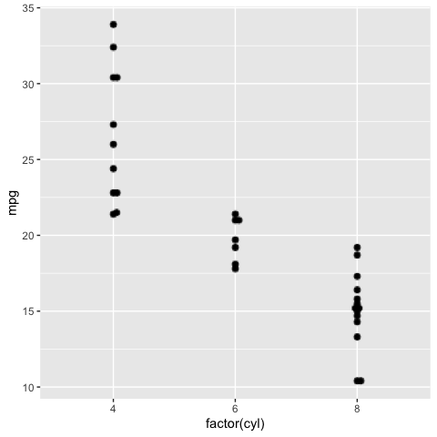

```r
library(ggplot2)
library(ggrastr)
library(ggbeeswarm,)
ggplot(mtcars) + rasterise(geom_beeswarm(aes(x = factor(cyl), y=mpg)))
```

Analogously, the legacy wrapper `geom_quasirandom_rast()` is much like `ggbeeswarm::geom_quasirandom()`, but with a rasterized layer:

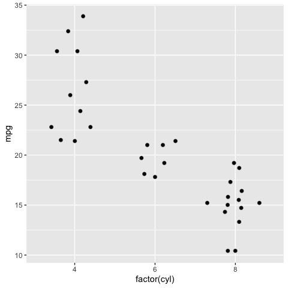

```r
library(ggplot2)
library(ggrastr)
ggplot(mtcars) + geom_quasirandom_rast(aes(x = factor(cyl), y=mpg), raster.dpi=600)
```

We encourage users to visit both [CRAN](https://CRAN.R-project.org/package=ggbeeswarm) and the [GitHub repo for ggbeeswam](https://github.com/eclarke/ggbeeswarm) for more details.